# DETSI Report

Author

EP Consulting and Dumelle Consulting

# Background

Accurately characterizing drivers and resilience of seagrass cover is essential to improving the ecological health of the Moreton Bay and Wide Bay ecosystems. Over the past few decades, various scientific efforts have informed our current understanding of trends, behaviors, and flood responses of seagrass cover in both Moreton Bay and Wide Bay (Preen, Long, and Coles 1995; McMahon et al. 2005; York, Bryant, and Rasheed 2022) (Abal and Dennison 1996; Udy and Dennison 1997; Samper-Villarreal et al. 2016; Ovsyanikova, Venables, and Udy 2026) as well as Australia more widely (Kilminster et al. 2015; Gilby et al. 2018; O’Brien et al. 2018). Remote sensing has offered new capabilities for seagrass cover mapping (Roelfsema and Phinn 2009), while innovative statistical approaches have offered novel methods for studying resilience at site-specific scales (Gilby et al. 2023). Our work contributes to this body of literature by applying spatially explicit statistical models (Cressie 1993) to study seagrass cover drivers, resilience, and recovery in both Moreton Bay and Wide Bay. Specifically, we provide and contextualize answers to four specific research questions, applicable to both Moreton Bay and Wide Bay:

1. Can we identify water quality covariates that act as triggers for seagrass cover management responses? Are these triggers different based on whether they result from a specific event (e.g., flood) or are ambient?
2. Did seagrass cover improve after the flood event(s)? If so, how and where?
3. Can we identify site-specific resilience indicators, which describe where recovery is likely to be enhanced or impeded?
4. What factors contribute to seagrass resilience?

The spatially explicit statistical models (i.e., spatial models) we used to answer these research questions are related to commonly used linear and generalized linear models but incorporate *spatial dependence* Spatial dependence measures how similar two sites are based on their distance. Formally, we can build spatial dependence directly into spatial models by leveraging Tobler’s First Law of Geography (Tobler 1970), which states succinctly that “nearby sites tend to be more similar than distant sites”. Not only is this intuitive based on “first principles” perspective, but spatial models to provide many advantages for modeling spatial data compared to models that assume independence among observations (i.e., nonspatial models). First, nonspatial models tend to underestimate uncertainty, yielding covariate standard errors and p-values for covariates that are too small and corresponding confidence intervals that are too narrow. Second, spatial models improve prediction at unsampled locations by borrowing strength from nearby observations, yielding more precise predictions and corresponding standard errors that vary by location. Third, spatial models decompose model error into separate spatial and nonspatial components, informing residual and resilience structure in ways that nonspatial models cannot. Fourth, spatial models can provide ecologically meaningful insight into the spatial dependence structure of the process, informing relationships among measured and unmeasured variables as well as future sampling plans. Zimmerman and Ver Hoef (2024) provide a thorough review of spatial models for ecological and environmental data, providing more detail and justification for the claims made above.

Spatial models offer many benefits over commonly used machine learning algorithms like random forests (Breiman 2001; Cutler et al. 2007; Fox et al. 2017; James et al. 2017; Kuhn and Silge 2022). First, traditional machine learning algorithms do not incorporate spatial dependence and, by consequence, often perform worse than spatial models at characterizing important covariates and predicting at unobserved locations (Fox, Ver Hoef, and Olsen 2020). Second, machine learning algorithms struggle to quantify uncertainty in a principled manner, something spatial models excel at. Third, covariate inference is more straightforward using spatial models, as they naturally provide p-values that enable structured testing of hypotheses. Fourth, spatial models provide a rich set of diagnostics like leverage and Cook’s distances (Montgomery, Peck, and Vining 2021), quantities not generally defined for machine learning algorithms. This is not to say that machine learning algorithms cannot be very useful in ecological data analyses, but rather than spatial models are often a more effective tool for modeling spatial data. An exciting and developing area of statistical research involves incorporating spatial modeling strategies directly into machine learning algorithms (Saha, Basu, and Datta 2023; Heaton, Millane, and Rhodes 2025).

The first spatially explicit model we define is the spatial linear model. The spatial linear model is a *mixed-effects model* (Pinheiro and Bates 2000; Bolker 2015) written as

$$y_i = \beta_0 + \beta_1x_{1, i} + \beta_2x_{2, i} + ... + \beta_p x_{p, i} + \tau_i + \epsilon_i,
\tag{1}$$
where $i = 1, 2, ..., n$ indexes the $n$ observations. The quantity $y_i$ is the response variable (for observation $i$), the $\beta$ parameters are slope parameters controlling the covariates, $x_{j, i}$ (for $j = 1, 2, ..., p$). The random error $\tau_i$ is a spatial random error, and the random error $\epsilon_i$ is the nonspatial (i.e., independent) random error. The spatial random error is spatially structured, capturing spatial residual effects like environmental gradients we do not have data to represent. The nonspatial random error is not spatially structure and captures nonspatial residual effects like measurement error and microscale variation. The difference between a traditional (i.e., nonspatial) linear model and a spatial linear model is the inclusion of $\tau_i$ (in the spatial linear model). The spatial random error implied by $\tau_i$ is governed by a *spatial covariance function*. The spatial covariance function allows the model to incorporate spatial dependence, yielding the improved model performance previously described. Figure 1 shows three different spatial covariance functions that describe different ways the spatial covariance decays with distance. Model parameters and standard errors are estimated from data using likelihood-based (Patterson and Thompson 1971; Harville 1977; Wolfinger, Tobias, and Sall 1994) or semivariogram-based (Cressie 1985; Curriero and Lele 1999) estimation methods. Often, the spatial linear model in Equation 1 in is written more compactly using *matrix notation*:
$$\mathbf{y} = \mathbf{X} \boldsymbol{\beta} + \boldsymbol{\tau} + \boldsymbol{\epsilon},
\tag{2}$$
where $\mathbf{X}$ is a matrix that holds the $j$ covariates for each of $n$ observations, and $\mathbf{y}$, $\boldsymbol{\beta}$, $\boldsymbol{\tau}$, and $\boldsymbol{\tau}$ are vectors that contain each of the $n$ or $j$ quantities from Equation 1. For more information about specific forms of various spatial covariance functions, see Schabenberger and Gotway (2017) and Zimmerman and Ver Hoef (2024).

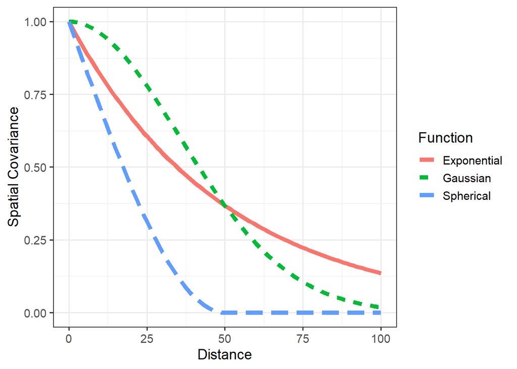

Figure 1: Three spatial covariance functions that represent different spatial dependence behavior.

One of the most useful applications of the spatial linear model is predicting the response variable at unobserved locations. A very useful spatial prediction method called Kriging has a rich theoretical justification (Cressie 1990; Stein 1999). Kriging is the spatial analogue to best linear unbiased prediction (BLUP) for mixed models (Henderson 1975). Via Kriging, the spatial linear model produces BLUPs at each unobserved location of interest, alongside prediction intervals to characterize uncertainty. While useful, sometimes the goal is to create a BLUP for an entire region of interest. This technique, which builds upon the theoretical foundations of Kriging, is called block Kriging (Ver Hoef 2002; Cressie 2006). The intution is to make point predictions at a very dense grid in the study region and then average these predictions, appropriately characterizing uncertainty. Together, Kriging and block Kriging provide a complete set of tools for spatial prediction, given the fit of a spatial linear model.

# Moreton Bay

## The Data

We started with 11,796 seagrass cover observations in Moreton Bay across three financial years (2020-2021, 2022-2023, and 2023-2024). eReefs data (Steven et al. 2019) with modeled water quality covariates related to turbidity and salinity were only available at 8,364 observaations. Because one of our research questions involved connecting water quality covariates to management actions, we proceed with this subset of 8,364 observations for modeling. Of the 8,364 observations, 1,995 were in 2020-2021 (pre-flood), 4,036 were in 2022-2023, and 2,333 were in 2023-2024 (Table 1). Total cover is a percentage that ranges from 0 (no seagrass) to 100 (seagrass entirely contained in an area). Figure 2 shows total cover by financial year throughout the Bay. Total cover tends to be largest along the eastern shoreline of the Bay and lowest in the middle of the Bay. Figure 2 also reveals that 2022-2023 had by far the most sampling in the middle of the Bay.

Table 1

| Financial Year | Sample Size | Percent (of Total) |
| --- | --- | --- |
| 2020-2021 | 1,995 | 23.9% |
| 2022-2023 | 4,036 | 48.3% |
| 2023-2024 | 2,333 | 27.9% |
| Total | 8,364 | 100.0% |

Total seagrass cover in Moreton Bay by financial year.

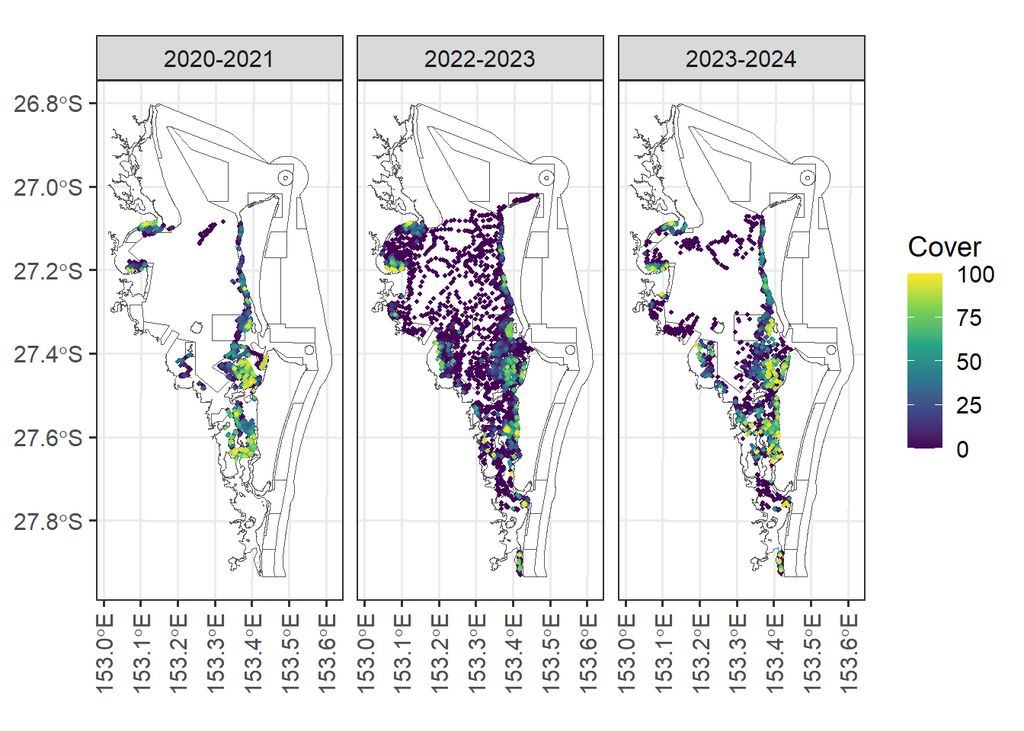

Figure 2: Total seagrass cover in Moreton Bay by financial year.

We considered for modeling several water quality and geographic covariates. Table 2 summarize these water quality variables, which included both ambient and flood-related metrics related to turbidity, salinity, and temperature. The “Variable” column indicates the water quality variable turbidity, salinity, or temperature. The “Flood” variable indicates whether the measurement corresponds to a flood variable or not. The “Period” variable indicates the prior period (in days) relative to sampling or indicates whether the variable corresponds to a flood event. The “Type” column is the type of statistic, either a mean, minimum, maximum, number of days above (or below) a cutoff during “Period”, or a maximum spell (i.e., duration) above (or below) a cutoff during “Period”. The “Included” variable indicates whether the variable was included as a covariate in the final spatial model.

Table 2

| Variable | Flood | Period | Type | Cutoff | Included |
| --- | --- | --- | --- | --- | --- |
| Turbidity | No | 7 | Mean | NA | No |
| Turbidity | No | 30 | Mean | NA | No |
| Turbidity | No | 90 | Mean | NA | Yes |
| Turbidity | No | 7 | Above | 3 | No |
| Turbidity | No | 30 | Above | 3 | No |
| Turbidity | No | 90 | Above | 3 | No |
| Turbidity | No | 7 | Above | 5 | No |
| Turbidity | No | 30 | Above | 5 | No |
| Turbidity | No | 90 | Above | 5 | No |
| Turbidity | No | 7 | Above | 6 | No |
| Turbidity | No | 30 | Above | 6 | No |
| Turbidity | No | 90 | Above | 6 | No |
| Turbidity | Yes | Flood | Above | 3 | No |
| Turbidity | Yes | Flood | Above | 5 | No |
| Turbidity | Yes | Flood | Above | 6 | No |
| Turbidity | Yes | Flood | Duration | 3 | No |
| Turbidity | Yes | Flood | Duration | 5 | No |
| Turbidity | Yes | Flood | Duration | 6 | No |
| Turbidity | Yes | Flood | Mean | NA | Yes |
| Turbidity | Yes | Flood | Max | NA | No |
| Salinity | No | 7 | Below | 20 | No |
| Salinity | No | 30 | Below | 20 | No |
| Salinity | No | 90 | Below | 20 | No |
| Salinity | No | 7 | Below | 25 | No |
| Salinity | No | 30 | Below | 25 | No |
| Salinity | No | 90 | Below | 25 | No |
| Salinity | No | 7 | Below | 30 | No |
| Salinity | No | 30 | Below | 30 | No |
| Salinity | No | 90 | Below | 30 | No |
| Salinity | Yes | Flood | Below | 20 | No |
| Salinity | Yes | Flood | Below | 25 | No |
| Salinity | Yes | Flood | Below | 30 | No |
| Salinity | Yes | Flood | Duration | 20 | No |
| Salinity | Yes | Flood | Duration | 25 | No |
| Salinity | Yes | Flood | Duration | 30 | No |
| Salinity | Yes | Flood | Mean | NA | Yes |
| Salinity | Yes | Flood | Min | NA | No |
| Temperature | No | 7 | Mean | NA | No |
| Temperature | No | 30 | Mean | NA | No |
| Temperature | No | 90 | Mean | NA | Yes |

Moreton Bay water quality variables considered for modeling.

# Wide Bay

## Outstanding Questions

- What are the units for the turbidity/salinity/temperature variables?

## References

Abal, EG, and WC Dennison. 1996. “Seagrass Depth Range and Water Quality in Southern Moreton Bay, Queensland, Australia.” *Marine and Freshwater Research* 47 (6): 763–71.

Bolker, Benjamin M. 2015. “Linear and Generalized Linear Mixed Models.” *Ecological Statistics: Contemporary Theory and Application* 2015: 309–33.

Breiman, Leo. 2001. “Random Forests.” *Machine Learning* 45 (1): 5–32.

Casella, George, and Roger Berger. 2024. *Statistical Inference*. Chapman; Hall/CRC.

Chambers, John M, and Trevor J Hastie. 1992. *Statistical Models in s*. Routledge.

Cressie, Noel. 1985. “Fitting Variogram Models by Weighted Least Squares.” *Journal of the International Association for Mathematical Geology* 17 (5): 563–86.

———. 1990. “The Origins of Kriging.” *Mathematical Geology* 22 (3): 239–52.

———. 1993. *Statistics for Spatial Data*. Hoboken, NJ: Wiley.

———. 2006. “Block Kriging for Lognormal Spatial Processes.” *Mathematical Geology* 38 (4): 413–43.

Curriero, Frank C, and Subhash Lele. 1999. “A Composite Likelihood Approach to Semivariogram Estimation.” *Journal of Agricultural, Biological, and Environmental Statistics*, 9–28.

Cutler, D Richard, Thomas C Edwards Jr, Karen H Beard, Adele Cutler, Kyle T Hess, Jacob Gibson, and Joshua J Lawler. 2007. “Random Forests for Classification in Ecology.” *Ecology* 88 (11): 2783–92.

Faraway, Julian James. 2002. *Practical Regression and ANOVA Using r.* Vol. 168. University of Bath Bath.

Fox, Eric W, Ryan A Hill, Scott G Leibowitz, Anthony R Olsen, Darren J Thornbrugh, and Marc H Weber. 2017. “Assessing the Accuracy and Stability of Variable Selection Methods for Random Forest Modeling in Ecology.” *Environmental Monitoring and Assessment* 189 (7): 316.

Fox, Eric W, Jay M Ver Hoef, and Anthony R Olsen. 2020. “Comparing Spatial Regression to Random Forests for Large Environmental Data Sets.” *PloS One* 15 (3): e0229509.

Gilby, Ben L, Lucy A Goodridge Gaines, Hayden P Borland, Christopher J Henderson, Jesse D Mosman, Andrew D Olds, and Hannah J Perry. 2023. “Drivers of Ecological Condition Identify Bright Spots and Sites for Management Across Coastal Seascapes.” *Estuaries and Coasts* 46 (4): 906–24.

Gilby, Ben L, Andrew D Olds, Rod M Connolly, Paul S Maxwell, Christopher J Henderson, and Thomas A Schlacher. 2018. “Seagrass Meadows Shape Fish Assemblages Across Estuarine Seascapes.” *Marine Ecology Progress Series* 588: 179–89.

Harville, David A. 1977. “Maximum Likelihood Approaches to Variance Component Estimation and to Related Problems.” *Journal of the American Statistical Association* 72 (358): 320–38.

Hastie, Trevor, Robert Tibshirani, Jerome Friedman, et al. 2009. “The Elements of Statistical Learning.” Springer series in statistics New-York.

Heaton, Matthew J, Andrew Millane, and Jake S Rhodes. 2025. “A Scalable Spatial Decorrelation Preprocessing Approach for Machine and Deep Learning.” *Journal of Data Science*, 1–15.

Henderson, Charles R. 1975. “Best Linear Unbiased Estimation and Prediction Under a Selection Model.” *Biometrics*, 423–47.

James, Gareth, Daniela Witten, Trevor Hastie, and Robert Tibshirani. 2017. *An Introduction to Statistical Learning with Applications in r*. Springer.

Kilminster, Kieryn, Kathryn McMahon, Michelle Waycott, Gary A Kendrick, Peter Scanes, Len McKenzie, Katherine R O’Brien, et al. 2015. “Unravelling Complexity in Seagrass Systems for Management: Australia as a Microcosm.” *Science of the Total Environment* 534: 97–109.

Kuhn, Max, and Julia Silge. 2022. *Tidy Modeling with r: A Framework for Modeling in the Tidyverse*. " O’Reilly Media, Inc.".

Lenth, Russell V., and Julia Piaskowski. 2025. *Emmeans: Estimated Marginal Means, Aka Least-Squares Means*. https://doi.org/10.32614/CRAN.package.emmeans.

McMahon, Kathryn, Susan Bengtson Nash, Geoff Eaglesham, Jochen F Müller, Norman C Duke, and Steve Winderlich. 2005. “Herbicide Contamination and the Potential Impact to Seagrass Meadows in Hervey Bay, Queensland, Australia.” *Marine Pollution Bulletin* 51 (1-4): 325–34.

Montgomery, Douglas C, Elizabeth A Peck, and G Geoffrey Vining. 2021. *Introduction to Linear Regression Analysis*. John Wiley & Sons.

O’Brien, Katherine R, Michelle Waycott, Paul Maxwell, Gary A Kendrick, James W Udy, Angus JP Ferguson, Kieryn Kilminster, et al. 2018. “Seagrass Ecosystem Trajectory Depends on the Relative Timescales of Resistance, Recovery and Disturbance.” *Marine Pollution Bulletin* 134: 166–76.

Ovsyanikova, E, WN Venables, and JW Udy. 2026. “Spatial and Temporal Modelling of Seagrass Distribution in Moreton Bay, Australia, Based on Long-Term Citizen Science Data.” *Estuarine, Coastal and Shelf Science* 328 (10961): 1.

Patterson, H Desmond, and Robin Thompson. 1971. “Recovery of Inter-Block Information When Block Sizes Are Unequal.” *Biometrika* 58 (3): 545–54.

Pedersen, Eric J, David L Miller, Gavin L Simpson, and Noam Ross. 2019. “Hierarchical Generalized Additive Models in Ecology: An Introduction with Mgcv.” *PeerJ* 7: e6876.

Pinheiro, José C, and Douglas M Bates. 2000. *Mixed-Effects Models in s and s-PLUS*. Springer.

Preen, AR, WJ Lee Long, and RG Coles. 1995. “Flood and Cyclone Related Loss, and Partial Recovery, of More Than 1000 Km2 of Seagrass in Hervey Bay, Queensland, Australia.” *Aquatic Botany* 52 (1-2): 3–17.

Roelfsema, CM, and SR Phinn. 2009. “An Integrated Field and Remote Sensing Approach for Mapping Seagrass Cover, Moreton Bay, Australia.” *Journal of Spatial Science* 54 (1): 45–62.

Saha, Arkajyoti, Sumanta Basu, and Abhirup Datta. 2023. “Random Forests for Spatially Dependent Data.” *Journal of the American Statistical Association* 118 (541): 665–83.

Samper-Villarreal, Jimena, Catherine E Lovelock, Megan I Saunders, Chris Roelfsema, and Peter J Mumby. 2016. “Organic Carbon in Seagrass Sediments Is Influenced by Seagrass Canopy Complexity, Turbidity, Wave Height, and Water Depth.” *Limnology and Oceanography* 61 (3): 938–52.

Schabenberger, Oliver, and Carol A Gotway. 2017. *Statistical Methods for Spatial Data Analysis*. Chapman; Hall/CRC.

Stein, Michael L. 1999. *Interpolation of Spatial Data: Some Theory for Kriging*. Springer Science & Business Media.

Steven, Andrew DL, Mark E Baird, Richard Brinkman, Nicholas J Car, Simon J Cox, Mike Herzfeld, Jonathan Hodge, et al. 2019. “eReefs: An Operational Information System for Managing the Great Barrier Reef.” *Journal of Operational Oceanography* 12 (sup2): S12–28.

Tibshirani, Robert. 1996. “Regression Shrinkage and Selection via the Lasso.” *Journal of the Royal Statistical Society Series B: Statistical Methodology* 58 (1): 267–88.

Tobler, Waldo R. 1970. “A Computer Movie Simulating Urban Growth in the Detroit Region.” *Economic Geography* 46 (sup1): 234–40.

Udy, James W, and William C Dennison. 1997. “Growth and Physiological Responses of Three Seagrass Species to Elevated Sediment Nutrients in Moreton Bay, Australia.” *Journal of Experimental Marine Biology and Ecology* 217 (2): 253–77.

Ver Hoef, Jay. 2002. “Sampling and Geostatistics for Spatial Data.” *Ecoscience* 9 (2): 152–61.

Wolfinger, Russ, Randy Tobias, and John Sall. 1994. “Computing Gaussian Likelihoods and Their Derivatives for General Linear Mixed Models.” *SIAM Journal on Scientific Computing* 15 (6): 1294–1310.

Wood, Simon N. 2017. *Generalized Additive Models: An Introduction with r*. chapman; hall/CRC.

York, Paul H, Catherine V Bryant, and Michael Rasheed. 2022. *Post-Flood Seagrass Monitoring in Hervey Bay May 2022*. Department of Environment; Science.

Zhang, Hao, and Dale L Zimmerman. 2005. “Towards Reconciling Two Asymptotic Frameworks in Spatial Statistics.” *Biometrika* 92 (4): 921–36.

Zimmerman, Dale L, and Jay M Ver Hoef. 2024. *Spatial Linear Models for Environmental Data*. Chapman; Hall/CRC.